# week_04_layers

## Group and aggregate

Calculate the number of rows associated with each unique value of Species.

```python
iris.Species.value_counts()
```

```
versicolor    50
virginica     50
setosa        50
Name: Species, dtype: int64
```

We can also do this with `groupby()` and `aggregate()`.

```python
iris.groupby(['Species']).\
aggregate(num_rows = ('Species', 'size'))
```

| Species | num_rows |
| --- | --- |
| setosa | 50 |
| versicolor | 50 |
| virginica | 50 |

```python
iris.groupby(['Species']).\
aggregate(num_rows = ('Species', 'size')).\
reset_index()
```

|  | Species | num_rows |
| --- | --- | --- |
| 0 | setosa | 50 |
| 1 | versicolor | 50 |
| 2 | virginica | 50 |

```python
iris.groupby(['Species']).\
aggregate(num_rows = ('Species', 'size'),
          num_non_missing = ('Species', 'count')).\
reset_index()
```

|  | Species | num_rows | num_non_missing |
| --- | --- | --- | --- |
| 0 | setosa | 50 | 50 |
| 1 | versicolor | 50 | 50 |
| 2 | virginica | 50 | 50 |

## Bar charts in Seaborn

Bar charts are known as countplots in Seaborn. The figure level function is `sns.catplot()` and the axes level function is `sns.countplot()`

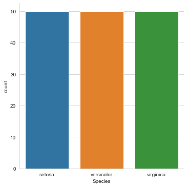

```python
sns.catplot(data = iris, x='Species', kind='count')

plt.show()
```

Alternatively we can use the axes level function.

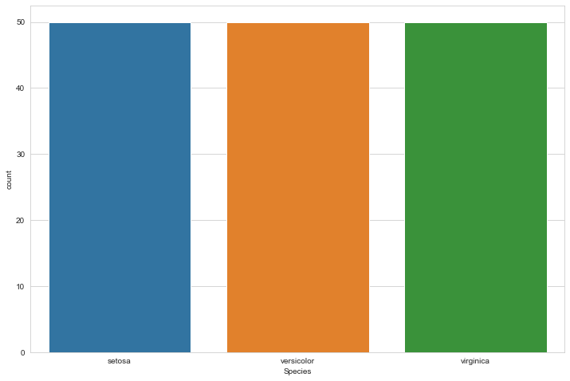

```python
fig, ax = plt.subplots(figsize=(12,8))

sns.countplot(data = iris, x='Species', ax=ax)

plt.show()
```

To print the number of rows on top of the bar, I base my approach on:

https://stackoverflow.com/questions/55104819/display-count-on-top-of-seaborn-barplot

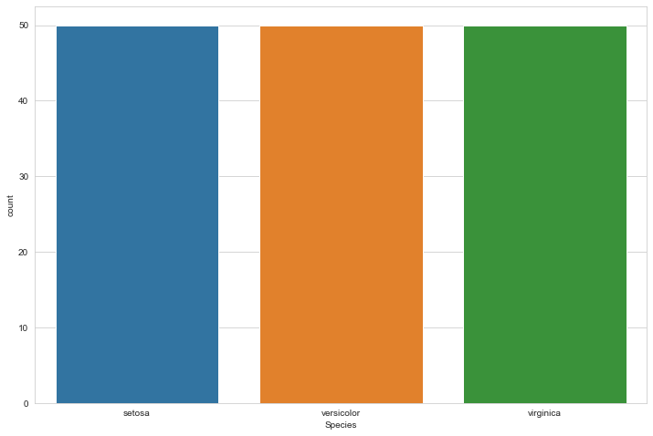

```python
fig, ax = plt.subplots(figsize=(12,8))

g = sns.countplot(data = iris, x='Species', ax=ax)
```

```python
g.patches
```

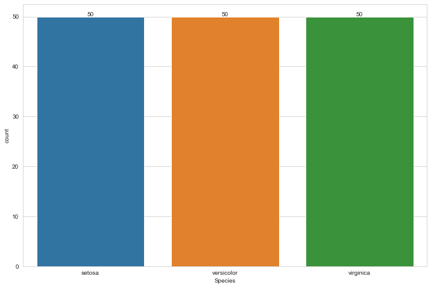

```python
fig, ax = plt.subplots(figsize=(12,8))

g = sns.countplot(data = iris, x='Species', ax=ax)

for p in g.patches:
    height = p.get_height()
    g.text(p.get_x() + p.get_width()/2.,
           height + 0.1,
           height,
           ha='center')

plt.show()
```

## Heat maps

We must count first before creating the heat map.

We can use `pd.crosstab()` to count the number of rows per combinations which is referred to as the **cross-tabulation**.

```python
iris_copy = iris.copy()
```

```python
iris_copy['length_bin'] = iris_copy['Sepal.Length'] > iris_copy['Sepal.Length'].mean()
```

```python
iris_copy
```

|  | Sepal.Length | Sepal.Width | Petal.Length | Petal.Width | Species | length_bin |
| --- | --- | --- | --- | --- | --- | --- |
| 0 | 5.1 | 3.5 | 1.4 | 0.2 | setosa | False |
| 1 | 4.9 | 3.0 | 1.4 | 0.2 | setosa | False |
| 2 | 4.7 | 3.2 | 1.3 | 0.2 | setosa | False |
| 3 | 4.6 | 3.1 | 1.5 | 0.2 | setosa | False |
| 4 | 5.0 | 3.6 | 1.4 | 0.2 | setosa | False |
| ... | ... | ... | ... | ... | ... | ... |
| 145 | 6.7 | 3.0 | 5.2 | 2.3 | virginica | True |
| 146 | 6.3 | 2.5 | 5.0 | 1.9 | virginica | True |
| 147 | 6.5 | 3.0 | 5.2 | 2.0 | virginica | True |
| 148 | 6.2 | 3.4 | 5.4 | 2.3 | virginica | True |
| 149 | 5.9 | 3.0 | 5.1 | 1.8 | virginica | True |

150 rows × 6 columns

```python
pd.crosstab(iris_copy.Species, iris_copy.length_bin)
```

| length_bin Species | False | True |
| --- | --- | --- |
| setosa | 50 | 0 |
| versicolor | 24 | 26 |
| virginica | 6 | 44 |

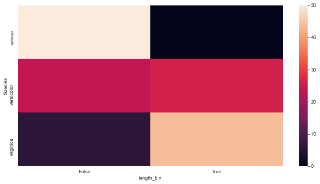

```python
fix, ax = plt.subplots(figsize=(12, 6))

sns.heatmap(pd.crosstab(iris_copy.Species,
                        iris_copy.length_bin),
            ax=ax)

plt.show()
```

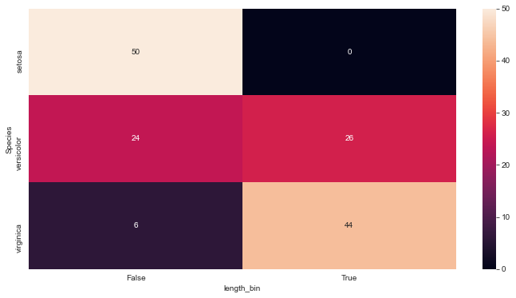

```python
fix, ax = plt.subplots(figsize=(12, 6))

sns.heatmap(pd.crosstab(iris_copy.Species,
                        iris_copy.length_bin),
            annot=True,
            ax=ax)

plt.show()
```

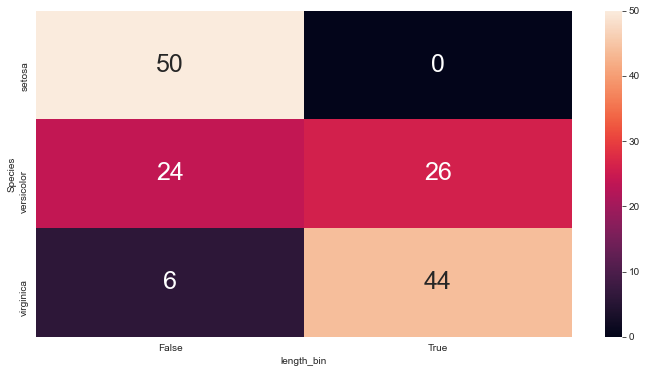

```python
fix, ax = plt.subplots(figsize=(12, 6))

sns.heatmap(pd.crosstab(iris_copy.Species,
                        iris_copy.length_bin),
            annot=True, annot_kws={'size': 25},
            ax=ax)

plt.show()
```

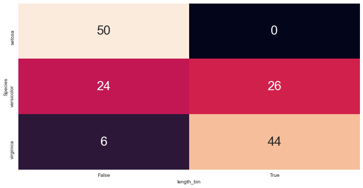

```python
fix, ax = plt.subplots(figsize=(12, 6))

sns.heatmap(pd.crosstab(iris_copy.Species,
                        iris_copy.length_bin),
            annot=True, annot_kws={'size': 25}, cbar=False,
            ax=ax)

plt.show()
```

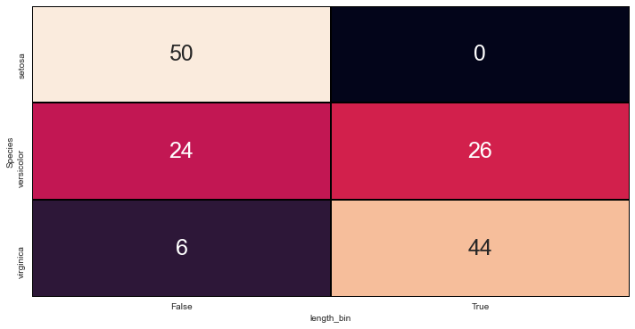

```python
fix, ax = plt.subplots(figsize=(12, 6))

sns.heatmap(pd.crosstab(iris_copy.Species,
                        iris_copy.length_bin),
            annot=True, annot_kws={'size': 25}, cbar=False,
            linewidths=0.75, linecolor='k',
            ax=ax)

plt.show()
```